# Association on Earthquakes

Nicholas Jacob

9/27/2021

I will use the same data from wikipedia on earthquakes in 2021 that I gathered [here](https://en.wikipedia.org/wiki/List_of_earthquakes_in_2021). The previous portion of this project was published [here](https://nurfnick.github.io/Data_Mining_R/EarthQuakes.html) I have not included all the data cleaning in this document even though it was all necessary. It is hidden in the first cell!

```r
tail(df)
```

```
## # A tibble: 6 × 9
##   Month     Day Country   Deaths Injuries    Mw Depth MMI   Offshore
##   <fct>   <int> <fct>      <int>    <int> <dbl> <dbl> <fct> <fct>
## 1 October    12 Greece         0        0   6.4  10   IX    on land
## 2 October    15 Solomon        0        0   6.4  22.6 VI    offshore
## 3 October    15 Indonesia      3       73   5.1  10   IV    on land
## 4 October    18 Vanuatu        0        0   6.1  96.5 V     offshore
## 5 October    21 Fiji           0        0   6   497.  II    offshore
## 6 October    24 Taiwan         0        1   6.2  64.5 VI    on land
```

## Association

```r
library(arules)
```

```r
library(arulesViz)
```

Added some new libraries. And now to convert the data for association analysis.

```r
transactions(df)
```

```
## transactions in sparse format with
##  179 transactions (rows) and
##  82 items (columns)
```

Lot’s of errors here! Let’s look at the columns and see if we can convert them into factors (or Boolean) for analysis.

```r
colnames(df)[c(2,4,5,6,7)]
```

```
## [1] "Day"      "Deaths"   "Injuries" "Mw"       "Depth"
```

I don’t think I can do anything with *Day* *Mw* or *Depth* but I could ask if there were any *Deaths* or *Injuries* since most were zeroed out in my data.

```r
df <- df %>% mutate(
  Deaths = (Deaths > 0),
  Injuries = (Injuries >0)
)
```

Then I’ll run the transactions again and see how it has cleaned up.

```r
as(df,"transactions")
```

```
## transactions in sparse format with
##  179 transactions (rows) and
##  82 items (columns)
```

```r
trans <- transactions(df)
```

I am happy to let R do the default discretization of the rest of the data. Partly because what is left I could not come up with better cutoffs. Depth, Mw and Day nothing strikes me as important. Day might be important in stock data but for a natural phenomenon, I can see no reason to chop it differently.

```r
summary(trans)
```

```
## transactions as itemMatrix in sparse format with
##  179 rows (elements/itemsets/transactions) and
##  82 columns (items) and a density of 0.09020302
##
## most frequent items:
## Offshore=offshore     Depth=[10,22)  Offshore=on land       Day=[18,31]
##               105                96                74                65
##      Mw=[6.2,8.2]           (Other)
##                65               919
##
## element (itemset/transaction) length distribution:
## sizes
##   7   8   9
## 126  35  18
##
##    Min. 1st Qu.  Median    Mean 3rd Qu.    Max.
##   7.000   7.000   7.000   7.397   8.000   9.000
##
## includes extended item information - examples:
##           labels variables   levels
## 1    Month=April     Month    April
## 2   Month=August     Month   August
## 3 Month=February     Month February
##
## includes extended transaction information - examples:
##   transactionID
## 1             1
## 2             2
## 3             3
```

```r
colnames(trans)
```

```
##  [1] "Month=April"              "Month=August"
##  [3] "Month=February"           "Month=January"
##  [5] "Month=July"               "Month=June"
##  [7] "Month=March"              "Month=May"
##  [9] "Month=October"            "Month=September"
## [11] "Day=[1,10)"               "Day=[10,18)"
## [13] "Day=[18,31]"              "Country=Algeria"
## [15] "Country=Antarctica"       "Country=Argentina"
## [17] "Country=Armenia"          "Country=Australia"
## [19] "Country=Chile"            "Country=China"
## [21] "Country=Colombia"         "Country=Croatia"
## [23] "Country=Democratic"       "Country=El"
## [25] "Country=Fiji"             "Country=France"
## [27] "Country=Greece"           "Country=Guyana"
## [29] "Country=Haiti"            "Country=Iceland"
```

[output cut: 26 more lines]

```r
inspect(trans[1:3])
```

```
##     items                   transactionID
## [1] {Month=January,
##      Day=[1,10),
##      Country=United States,
##      Mw=[6,6.2),
##      Depth=[10,22),
##      MMI=VI,
##      Offshore=offshore}                 1
## [2] {Month=January,
##      Day=[1,10),
##      Country=New Zealand,
##      Mw=[6.2,8.2],
##      Depth=[22,600],
##      MMI=IV,
##      Offshore=offshore}                 2
## [3] {Month=January,
##      Day=[1,10),
##      Country=Croatia,
##      Mw=[4.2,6),
##      Depth=[10,22),
##      MMI=VIII,
##      Offshore=on land}                  3
```

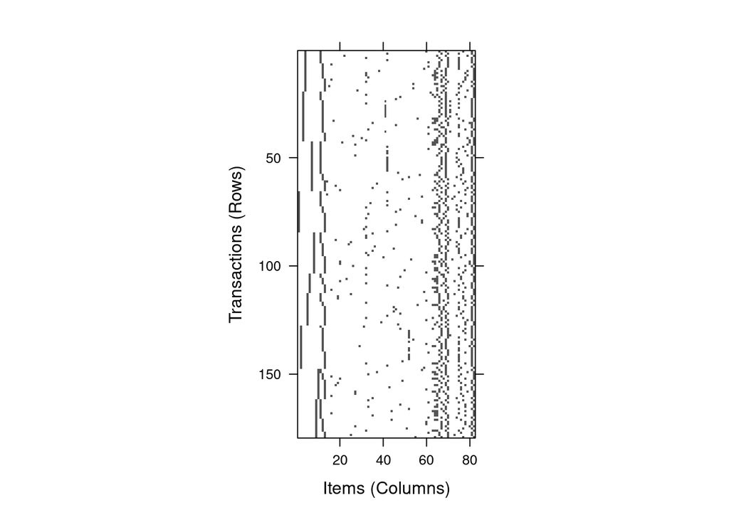

```r
image(trans)
```

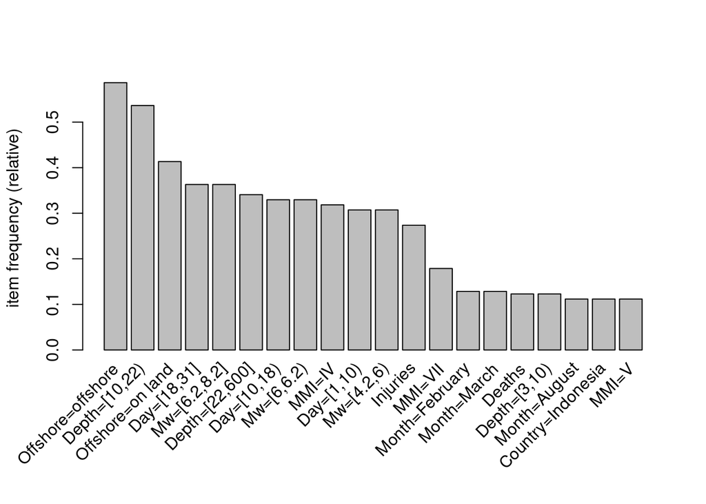

```r
itemFrequencyPlot(trans,topN = 20)
```

```r
vertical <- as(trans, "tidLists")
as(vertical, "matrix")[1:10, 1:5]
```

```
##                     1     2     3     4     5
## Month=April     FALSE FALSE FALSE FALSE FALSE
## Month=August    FALSE FALSE FALSE FALSE FALSE
## Month=February  FALSE FALSE FALSE FALSE FALSE
## Month=January    TRUE  TRUE  TRUE  TRUE  TRUE
## Month=July      FALSE FALSE FALSE FALSE FALSE
## Month=June      FALSE FALSE FALSE FALSE FALSE
## Month=March     FALSE FALSE FALSE FALSE FALSE
## Month=May       FALSE FALSE FALSE FALSE FALSE
## Month=October   FALSE FALSE FALSE FALSE FALSE
## Month=September FALSE FALSE FALSE FALSE FALSE
```

```r
trans
```

```
## transactions in sparse format with
##  179 transactions (rows) and
##  82 items (columns)
```

```r
trans_Nepal <- trans[trans %in% "Country=Nepal"]
trans_Nepal
```

```
## transactions in sparse format with
##  1 transactions (rows) and
##  82 items (columns)
```

```r
inspect(trans_Nepal)
```

```
##     items              transactionID
## [1] {Month=May,
##      Day=[18,31],
##      Country=Nepal,
##      Injuries,
##      Mw=[4.2,6),
##      Depth=[10,22),
##      MMI=V,
##      Offshore=on land}            96
```

Looks like there was only one earthquake in Nepal during May and it did cause injuries.

Let’s find some frequent itemsets

```r
its <- apriori(trans, parameter=list(target = "frequent"))
```

```
## Apriori
##
## Parameter specification:
##  confidence minval smax arem  aval originalSupport maxtime support minlen
##          NA    0.1    1 none FALSE            TRUE       5     0.1      1
##  maxlen            target  ext
##      10 frequent itemsets TRUE
##
## Algorithmic control:
##  filter tree heap memopt load sort verbose
##     0.1 TRUE TRUE  FALSE TRUE    2    TRUE
##
## Absolute minimum support count: 17
##
## set item appearances ...[0 item(s)] done [0.00s].
## set transactions ...[82 item(s), 179 transaction(s)] done [0.00s].
## sorting and recoding items ... [26 item(s)] done [0.00s].
## creating transaction tree ... done [0.00s].
## checking subsets of size 1 2 3 4 done [0.00s].
## sorting transactions ... done [0.00s].
## writing ... [92 set(s)] done [0.00s].
## creating S4 object  ... done [0.00s].
```

```r
its
```

```
## set of 92 itemsets
```

```r
inspect(head(its, n = 10))
```

```
##      items                 support   transIdenticalToItemsets count
## [1]  {Country=New Zealand} 0.1061453 0                        19
## [2]  {Month=October}       0.1005587 0                        18
## [3]  {Month=April}         0.1061453 0                        19
## [4]  {Month=January}       0.1061453 0                        19
## [5]  {Month=May}           0.1061453 0                        19
## [6]  {MMI=VI}              0.1117318 0                        20
## [7]  {Month=August}        0.1117318 0                        20
## [8]  {MMI=V}               0.1117318 0                        20
## [9]  {Country=Indonesia}   0.1117318 0                        20
## [10] {Month=March}         0.1284916 0                        23
```

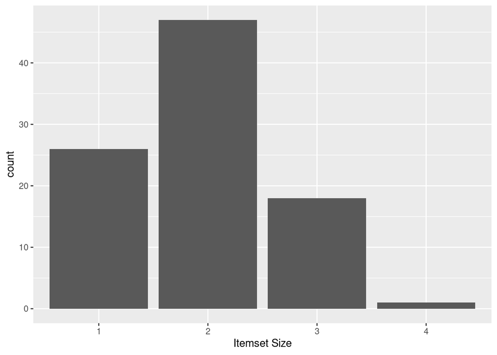

```r
ggplot(tibble(`Itemset Size` = factor(size(its))), aes(`Itemset Size`)) + geom_bar()
```

Now we’ll build some rules. Very similar to looking at frequent!

```r
rules <- apriori(trans, parameter = list(support = 0.05, confidence = 0.9))
```

```
## Apriori
##
## Parameter specification:
##  confidence minval smax arem  aval originalSupport maxtime support minlen
##         0.9    0.1    1 none FALSE            TRUE       5    0.05      1
##  maxlen target  ext
##      10  rules TRUE
##
## Algorithmic control:
##  filter tree heap memopt load sort verbose
##     0.1 TRUE TRUE  FALSE TRUE    2    TRUE
##
## Absolute minimum support count: 8
##
## set item appearances ...[0 item(s)] done [0.00s].
## set transactions ...[82 item(s), 179 transaction(s)] done [0.00s].
## sorting and recoding items ... [33 item(s)] done [0.00s].
## creating transaction tree ... done [0.00s].
## checking subsets of size 1 2 3 4 5 done [0.00s].
## writing ... [63 rule(s)] done [0.00s].
## creating S4 object  ... done [0.00s].
```

```r
inspect(head(rules))
```

```
##     lhs                        rhs                    support confidence   coverage     lift count
## [1] {Country=Vanuatu}       => {Offshore=offshore} 0.05027933  1.0000000 0.05027933 1.704762     9
## [2] {Country=South Georgia} => {Offshore=offshore} 0.07262570  1.0000000 0.07262570 1.704762    13
## [3] {Country=New Zealand}   => {Offshore=offshore} 0.10614525  1.0000000 0.10614525 1.704762    19
## [4] {Mw=[4.2,6)}            => {Offshore=on land}  0.29050279  0.9454545 0.30726257 2.286978    52
## [5] {Month=August,
##      Country=South Georgia} => {Offshore=offshore} 0.05586592  1.0000000 0.05586592 1.704762    10
## [6] {Month=March,
##      Country=New Zealand}   => {Day=[1,10)}        0.05586592  1.0000000 0.05586592 3.254545    10
```

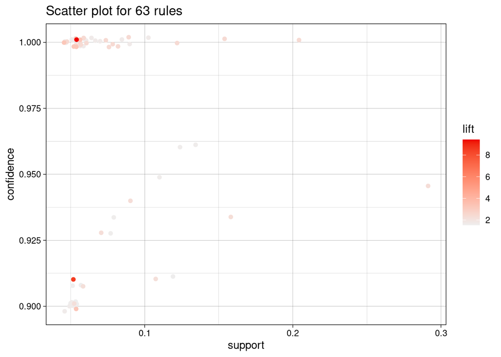

```r
plot(rules,jitter = 1)
```

```
## To reduce overplotting, jitter is added! Use jitter = 0 to prevent jitter.
```

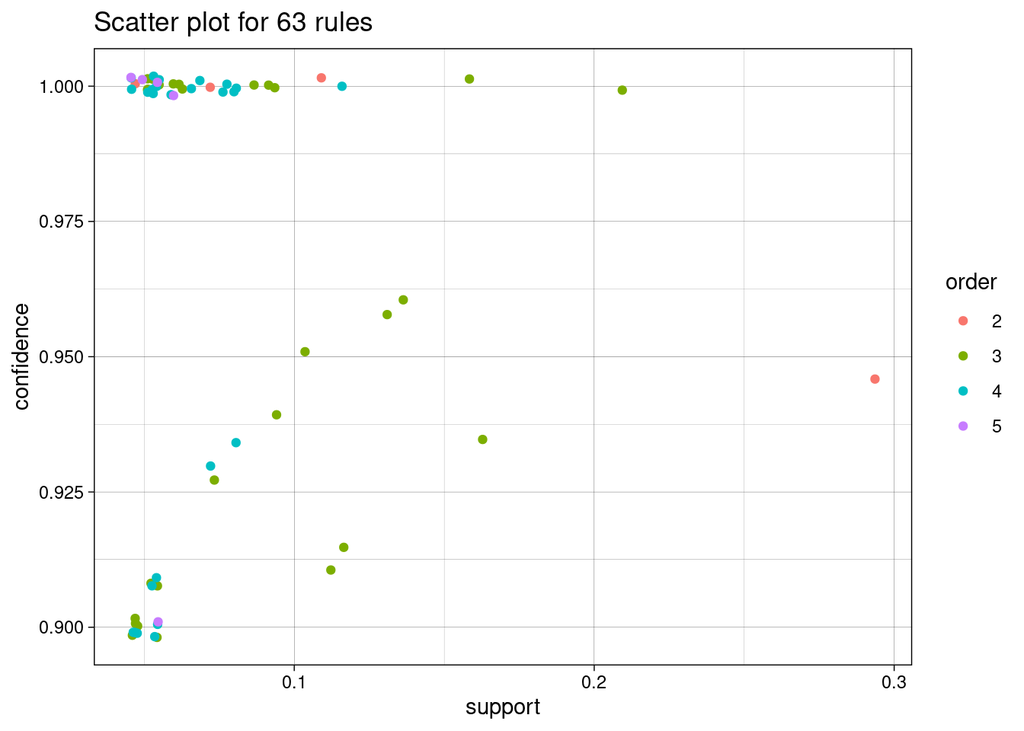

```r
plot(rules, shading = "order")
```

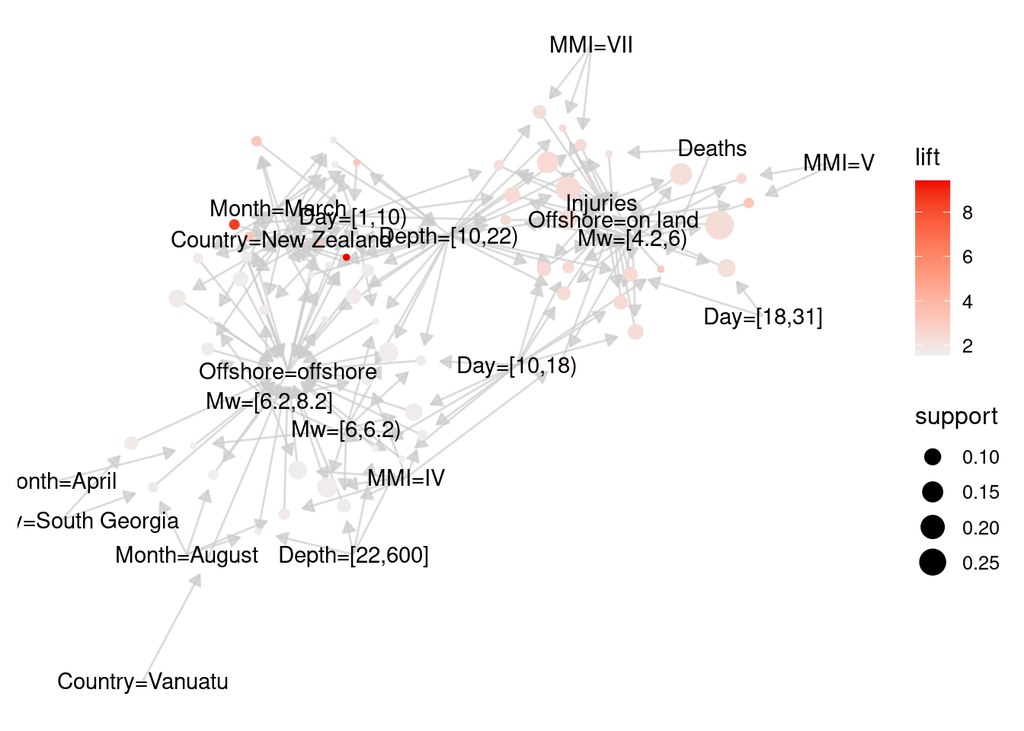

```r
plot(head(rules, n = 100), method = "graph")
```